# 18. 이미지 검출 (윤곽선)

## 윤곽선 (Contour) : 경계선을 연결한 선

## 윤곽선 찾기 모드

1. cv2.RETR_EXTERNAL : 가장 외곽의 윤곽선만 찾음
2. cv2.RETR_LIST : 모든 윤곽선 찾음 (계층 정보 없음)
3. cv2.RETR_TREE : 모든 윤곽선 찾음 (계층 정보를 트리 구조로 생성)

> RETR_LIST

```python
import cv2
img = cv2.imread('card.png') # 원본 이미지
target_img = img.copy() # 사본 이미지

gray = cv2.cvtColor(img, cv2.COLOR_BGR2GRAY) # 원본 이미지를 흑백 이미지로 바꿔서 단순화
ret, otsu = cv2.threshold(gray, -1, 255, cv2.THRESH_BINARY | cv2.THRESH_OTSU) # threshold를 통해 이진화 (otsu 알고리즘으로 최적의 임계치를 자동으로 구함)
# threshold (-1) 값은 otsu가 자동으로 발견해서 사용하는 것이기 때문에 의미 x
# 임계치를 초과하는 값은 모두 255로 처리
# otsu를 적용하기 위해서 BINARY 이미지로 처리함
#otsu 알고리즘을 통해서 최적의 임계치를 찾아가지고 BINARY 이미지를 반환해준다.


contours, hierarchy = cv2.findContours(otsu, cv2.RETR_LIST, cv2.CHAIN_APPROX_NONE) #윤곽선 검출
# 윤곽선 정보(contours), 계층 구조(hierarchy)
# findContours : 이미지, 윤곽선 찾는 모드 (mode), 윤곽선 찾을 때 사용하는 근사치 방법 (method)
# 윤곽선 찾을 때 사용하는 근사치 방법 (method) : CHAIN_APPROX_NONE (윤곽선의 모든 좌표 반환), CHAIN_APPROX_SIMPLE (꼭짓점 좌표만 보여줌, 중복 제거)

COLOR = (0, 200, 0) # 녹색
cv2.drawContours(target_img, contours, -1, COLOR, 2 ) # 윤곽선 그리기
# drawContours : 대상 이미지, 윤곽선 정보, 인덱스 (-1이면 전체 윤곽선을 그림), 색깔, 두께

cv2.imshow('img', img)
cv2.imshow('gray', gray)
cv2.imshow('otsu', otsu)
cv2.imshow('contour', target_img)

cv2.waitKey(0)
cv2.destroyAllWindows()
```

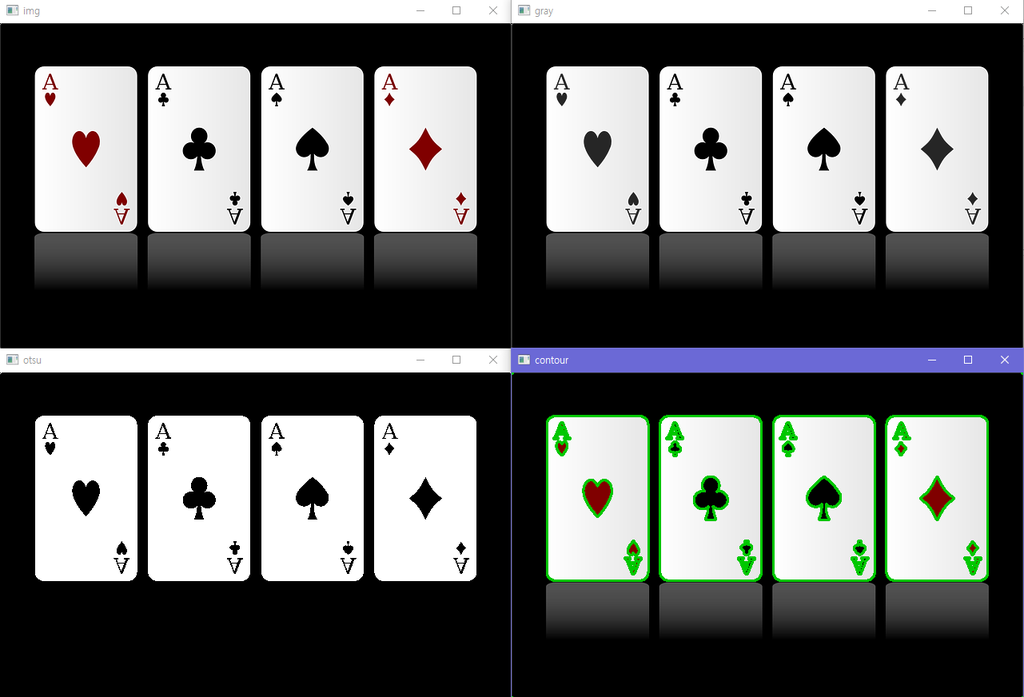

img : 원본 이미지  
gray : 원본 이미지를 흑백으로 전환  
otsu : otsu 알고리즘(최적의 임계치)을 통해 이진화 contour : otsu 이미지로부터 찾은 윤곽선 정보를 그림 (target_img)

윤곽선을 검출할 때 정확도를 높히기 위해 BINARY 이미지를 사용해서 Threshold, Canny Edge Detection 같은 걸로 이미지 전처리를 수용함.  
윤곽선을 검출하는 findContours 함수는 원본 이미지를 직접 수정하는 함수이기 때문에 원본 이미지를 보존하기 위해 사본 이미지로 작업을 수행함.

> RETR_EXTERNAL

```python
import cv2
img = cv2.imread('card.png')
target_img = img.copy()

gray = cv2.cvtColor(img, cv2.COLOR_BGR2GRAY)
ret, otsu = cv2.threshold(gray, -1, 255, cv2.THRESH_BINARY | cv2.THRESH_OTSU)

#contours, hierarchy = cv2.findContours(otsu, cv2.RETR_LIST, cv2.CHAIN_APPROX_NONE)
contours, hierarchy = cv2.findContours(otsu, cv2.RETR_EXTERNAL, cv2.CHAIN_APPROX_NONE)

COLOR = (0, 200, 0)
cv2.drawContours(target_img, contours, -1, COLOR, 2 )

cv2.imshow('img', img)
cv2.imshow('gray', gray)
cv2.imshow('otsu', otsu)
cv2.imshow('contour', target_img)

cv2.waitKey(0)
cv2.destroyAllWindows()
```

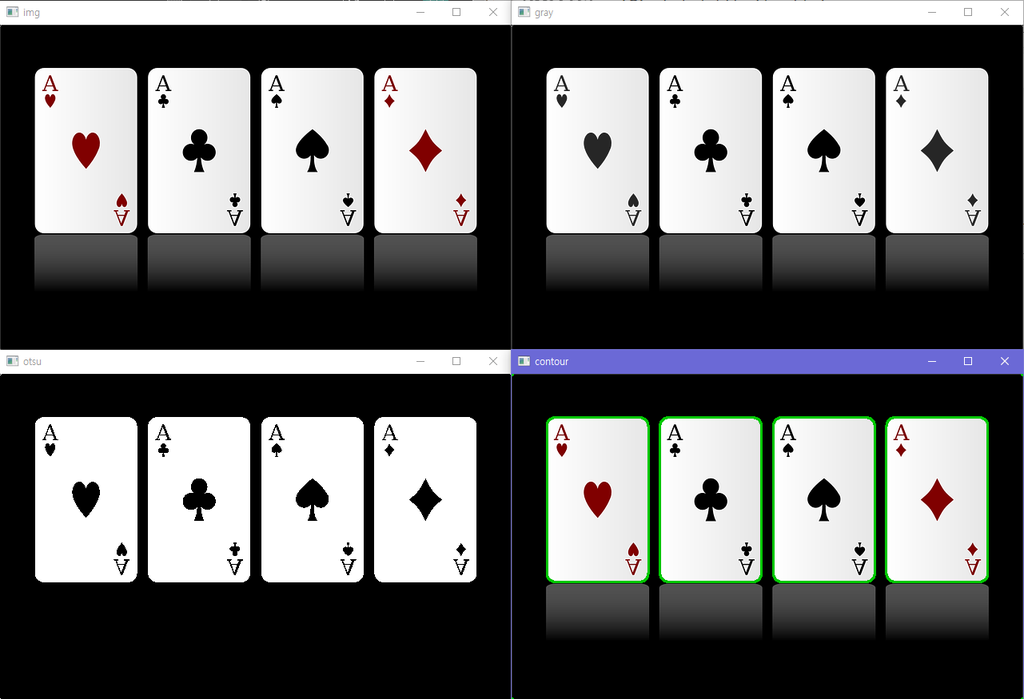

> RETR_TREE

```python
import cv2
img = cv2.imread('card.png')
target_img = img.copy()

gray = cv2.cvtColor(img, cv2.COLOR_BGR2GRAY)
ret, otsu = cv2.threshold(gray, -1, 255, cv2.THRESH_BINARY | cv2.THRESH_OTSU)

#contours, hierarchy = cv2.findContours(otsu, cv2.RETR_LIST, cv2.CHAIN_APPROX_NONE)
contours, hierarchy = cv2.findContours(otsu, cv2.RETR_TREE, cv2.CHAIN_APPROX_NONE)
print(hierarchy)
print(f'총 발견 갯수 : {len(contours)}')
# 윤곽선 정보 : contours

COLOR = (0, 200, 0)
cv2.drawContours(target_img, contours, -1, COLOR, 2 )

cv2.imshow('img', img)
cv2.imshow('gray', gray)
cv2.imshow('otsu', otsu)
cv2.imshow('contour', target_img)

cv2.waitKey(0)
cv2.destroyAllWindows()
```

```
[[[ 1 -1 -1 -1]
  [ 2  0 -1 -1]
  [10  1  3 -1]
  [ 5 -1  4  2]
  [-1 -1 -1  3]
  [ 6  3 -1  2]
  [ 7  5 -1  2]
  [ 8  6 -1  2]
  [-1  7  9  2]
  [-1 -1 -1  8]
  [18  2 11 -1]
  [13 -1 12 10]
  [-1 -1 -1 11]
  [14 11 -1 10]
  [15 13 -1 10]
  [16 14 -1 10]
  [-1 15 17 10]
  [-1 -1 -1 16]
  [26 10 19 -1]
  [21 -1 20 18]
  [-1 -1 -1 19]
  [22 19 -1 18]
  [23 21 -1 18]
  [24 22 -1 18]
  [-1 23 25 18]
  [-1 -1 -1 24]
  [34 18 27 -1]
  [29 -1 28 26]
  [-1 -1 -1 27]
  [30 27 -1 26]
  [31 29 -1 26]
  [32 30 -1 26]
  [-1 31 33 26]
  [-1 -1 -1 32]
  [35 26 -1 -1]
  [-1 34 -1 -1]]]
총 발견 갯수 : 36
```

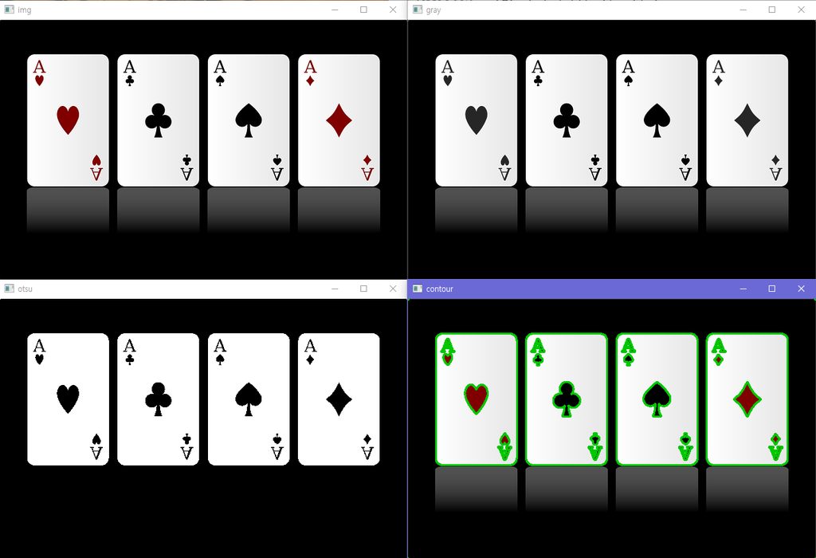

## 경계 사각형

윤곽선의 경계면을 둘러싸는 사각형

> boundingRect()

```python
import cv2
img = cv2.imread('card.png')
target_img = img.copy()

gray = cv2.cvtColor(img, cv2.COLOR_BGR2GRAY)
ret, otsu = cv2.threshold(gray, -1, 255, cv2.THRESH_BINARY | cv2.THRESH_OTSU)
contours, hierarchy = cv2.findContours(otsu, cv2.RETR_LIST, cv2.CHAIN_APPROX_NONE)

COLOR = (0, 200, 0) # 녹색

for cnt in contours:
    x, y, width, height = cv2.boundingRect(cnt)
    cv2.rectangle(target_img, (x,y), (x+width, y+height), COLOR, 2) # 사각형 그림

cv2.imshow('img', img)
cv2.imshow('gray', gray)
cv2.imshow('otsu', otsu)
cv2.imshow('contour', target_img)

cv2.waitKey(0)
cv2.destroyAllWindows()
```

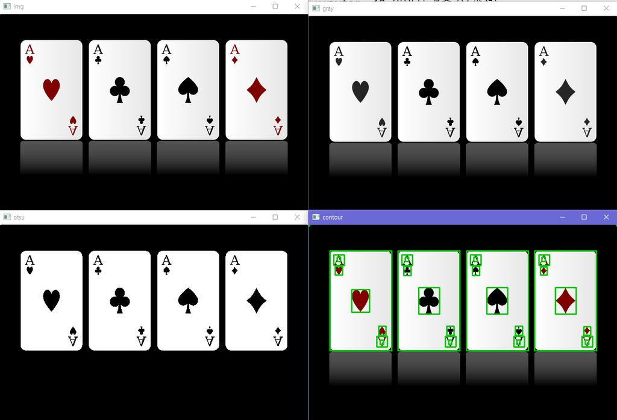

## 면적

> contourArea()

```python
import cv2
img = cv2.imread('card.png')
target_img = img.copy()

gray = cv2.cvtColor(img, cv2.COLOR_BGR2GRAY)
ret, otsu = cv2.threshold(gray, -1, 255, cv2.THRESH_BINARY | cv2.THRESH_OTSU)
contours, hierarchy = cv2.findContours(otsu, cv2.RETR_LIST, cv2.CHAIN_APPROX_NONE)

COLOR = (0, 200, 0) # 녹색

for cnt in contours:
    if cv2.contourArea(cnt) > 25000: # 카드 한 장 크기 : 가로 130 x 세로 205 = 26,650
        x, y, width, height = cv2.boundingRect(cnt)
        cv2.rectangle(target_img, (x,y), (x+width, y+height), COLOR, 2) # 사각형 그림

cv2.imshow('img', img)
cv2.imshow('contour', target_img)

cv2.waitKey(0)
cv2.destroyAllWindows()
```

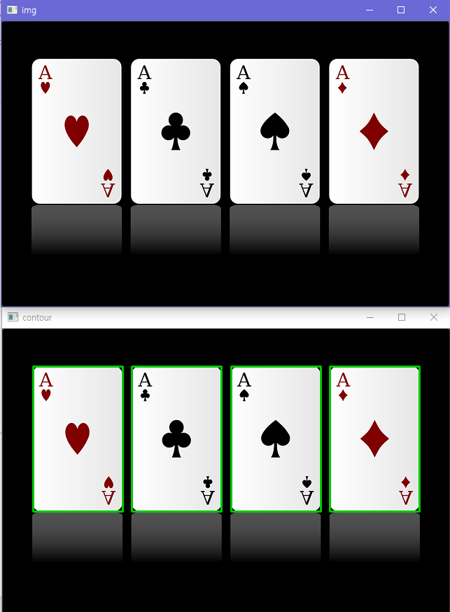

## 개별 카드 추출해서 파일 저장

```python
import cv2
img = cv2.imread('card.png')
target_img = img.copy()

gray = cv2.cvtColor(img, cv2.COLOR_BGR2GRAY)
ret, otsu = cv2.threshold(gray, -1, 255, cv2.THRESH_BINARY | cv2.THRESH_OTSU)
contours, hierarchy = cv2.findContours(otsu, cv2.RETR_LIST, cv2.CHAIN_APPROX_NONE)

COLOR = (0, 200, 0) # 녹색

idx = 1
for cnt in contours:
    if cv2.contourArea(cnt) > 25000:
        x, y, width, height = cv2.boundingRect(cnt)
        cv2.rectangle(target_img, (x,y), (x+width, y+height), COLOR, 2)

        crop = img [y:y+height, x:x+width] # 원본 이미지에서 윤곽선 영역만큼 잘라내서 crop 변수에 저장
        cv2.imshow(f'card_crop_{idx}', crop) # card_crop_{idx} 창을 뜨게 함
        cv2.imwrite(f'card_crop_{idx}.png', crop) # 파일 저장
        idx += 1 # 새로운 창 떠지게

cv2.imshow('img', img)
cv2.imshow('contour', target_img)

cv2.waitKey(0)
cv2.destroyAllWindows()
```

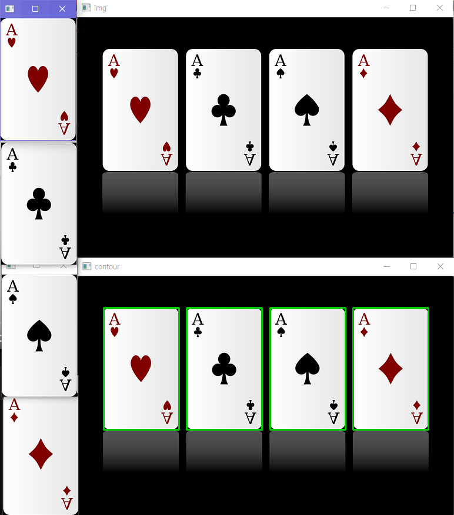

원본 이미지로부터 특정 크기 이상이 되는 사각형 윤곽선을 찾아가지고 그 이미지를 떼와서 별도 파일로 저장함.

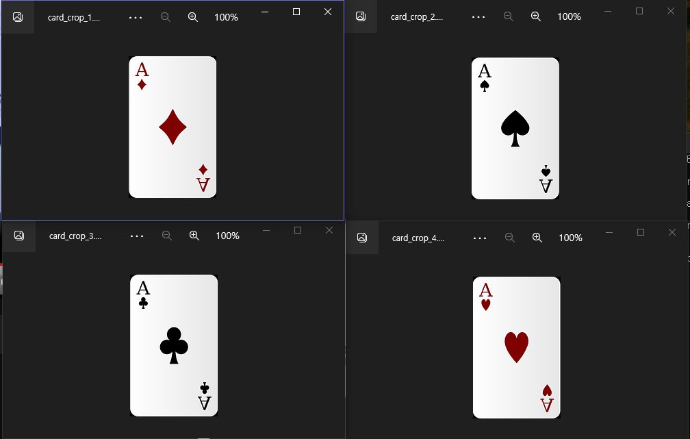

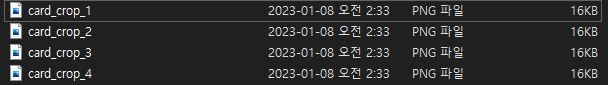